# Olfactory Dysfunction and Wake-State Behavioral Fragmentation in NHANES 2013–2014

**Ceyhun Olcan¹,²**

¹ Department of Biomedical Engineering, Thayer School of Engineering, Dartmouth College, Hanover, NH 03755, USA ² Center for Technology and Behavioral Health, Geisel School of Medicine at Dartmouth, Lebanon, NH 03766, USA

**Correspondence:** ceyhun.olcan.27@dartmouth.edu **ORCID:** 0000-0002-6326-6071

## ABSTRACT

**Background.** Olfactory dysfunction (OD) predicts dementia, frailty, and 5-year mortality, but the behavioral pathway is unknown. The conventional account is sensory-motivational and food-mediated, untested directly.

**Methods.** Cross-sectional analysis of 2,327 NHANES 2013–2014 participants aged ≥40 with 8-item Pocket Smell Test (PST) and ≥4 valid days of wrist accelerometry, using survey-weighted cluster-robust regression with Benjamini-Hochberg FDR. Five primary outcomes (mean MIMS, MVPA min/day, interdaily stability of 24-hour activity [IS], intradaily variability [IV], active-to-sedentary transition probability [ASTP]) were pre-specified. Four mechanistic analyses tested alternatives: odor-subtype falsification of food-appeal, mediation through depression and BMI, compositional analysis of the activity budget, and minute-level decomposition.

**Findings.** OD adults moved ~15% less than non-OD adults during waking hours but did not differ during sleep. The signature included reduced rhythm stability (IS Cohen’s *d* = −0.20), increased fragmentation (IV *d* = +0.21), and a quantitatively symmetric transition phenotype (ASTP *d* = +0.17; SATP *d* = −0.20; bootstrap symmetry *p* = 0.71). Sedentary bouts were longer; active maxima shorter. Food-odor deficit was unrelated to any activity outcome (all *p* ≥ 0.225). Depression-mediation was undetectable; BMI mediated 7–15% (CIs include zero). Frailty adjustment left OD effects essentially unchanged (attenuation ≤ 3%). Split-half replication confirmed direction-consistent effects for all primary outcomes except IV. Displaced minutes accumulated in nonwear, not sedentary time.

**Interpretation.** The integrated phenotype - preserved sleep activity, symmetric waking-hour transition dampening, and disengagement into nonwear - is more consistent with central than peripheral sensory-motivational mechanisms, though cross-sectional data cannot adjudicate this directly. The activity-rhythm signature warrants prospective testing in the OD–mortality association; paper #2 is pre-registered.

## INTRODUCTION

Olfactory dysfunction (OD), detectable in ~12% of U.S. adults aged ≥40[1], predicts incident dementia[5], frailty[6], and 5-year mortality[7,8] with effect sizes comparable to those of established clinical predictors. These associations are well-established. What is not established is the behavioral pathway connecting them - mortality and frailty are not direct consequences of impaired smell identification; some intermediate process must do the causal work, and reduced physical activity is the most-discussed candidate.

The conventional account for how OD reduces activity is sensory-motivational and food-mediated: olfactory loss reduces food appeal, which reduces eating engagement, which reduces energy intake and the metabolic substrate for activity. This account has the virtue of being concrete and testable, but has not been tested directly. The largest prior NHANES study - Namiranian et al.[2], using the same cycle and PST exposure - examined OD’s association with self-reported physical activity, finding small correlations (*r* ≈ 0.05–0.08) but no information about how activity is distributed across the day, no rhythm metrics, and no subtype-specific olfactory tests. The longitudinal Schubert et al.[4] study found regular exercise associated with 24% lower 10-year hazard of incident OD (HR 0.76, 95% CI 0.60–0.97), establishing a bidirectional relationship without identifying the mechanism running through it.

Wrist-worn accelerometry - added to NHANES 2011–12 and 2013–14 - supports analytic moves that self-report cannot. It allows the question *when* OD adults move less, with hour-by-hour resolution. It permits nonparametric rhythm metrics[12] capturing the regularity, fragmentation, and amplitude of daily behavioral organization - properties independently linked to mortality and biological aging[14,15]. It also permits minute-level decomposition of behavioral transitions and bout-length distributions, distinguishing whether OD reflects “cannot sustain activity,” “cannot break sedentary inertia,” or both.

We characterize the OD-associated signature across activity volume, 24-hour rhythm, sleep, and minute-level fragmentation, and run four pre-specified mechanistic analyses: a subtype falsification test of the food-appeal hypothesis using the four food vs. four non-food PST odors; counterfactual mediation through depression and body mass index (BMI); compositional data analysis of the 24-hour activity budget; and minute-level decomposition of transition probabilities, bout-length distributions, hazard rates, and time-of-day patterns. Together these analyses examine whether the OD–activity link operates through the most-cited mechanism (food appeal) or carries variance not explained by it, and characterize the temporal structure of the activity difference.

## METHODS

### Outcomes

Per-minute MIMS-triaxial values[10] and CDC state predictions were obtained from PAXMIN_H. Five primary outcomes were pre-specified for FDR-corrected family-wise testing: **mean MIMS** (volume), **MVPA min/day** (intensity), **interdaily stability (IS)** and **intradaily variability (IV)** (24-hour rhythm), and **active-to-sedentary transition probability (ASTP)** (fragmentation). Secondary outcomes included: sedentary and light min/day; relative amplitude (RA), most-active 10 hours (M10), least-active 5 hours (L5); total sleep time, wake after sleep onset (WASO), and sleep efficiency; the bout-level and minute-level features detailed below. We used Karas et al.[9] thresholds (sedentary <10.558, MVPA ≥37.5 MIMS/min) as primary, with Belcher et al.[11] thresholds in sensitivity (Table S6). Within each noon-to-noon window, the longest contiguous CDC-sleep-state run was identified, with adjacent sleep blocks ≤30 min apart merged[13]; periods <4 hours or touching the data boundary were excluded. The sleep-detection algorithm has not been independently validated against polysomnography in MIMS-summarized data; among 2,327 participants, 424 (18.2%) lacked a detectable main sleep period and these did not differ from the rest in OD prevalence (13.2% vs 13.3%, *p* = 1.00).

**Minute-level fragmentation phenotype.** From the per-minute wake-state stream, we computed: (a) active-to-sedentary transition probability (**ASTP**) and sedentary-to-active transition probability (**SATP**), capturing both directions of state-change; (b) bout-length distributions (mean, median, 90th percentile, maximum) for active and sedentary bouts; (c) prolonged-sitting exposures as the fraction of sedentary minutes in bouts ≥30 and ≥60 minutes; (d) discrete-time hazard rates at 1, 5, 15, 30, and 60 minutes distinguishing memoryless from memory-dependent transition processes (Table S18); and (e) time-of-day decomposition into morning (06:00–12:00), afternoon (12:00–18:00), and evening (18:00–24:00) windows. Bouts and transitions were computed within contiguous wake blocks (PAXSSNMP gap ≤ 1 minute) so that across-sleep concatenation could not produce spurious extra-long bouts or extra transitions. The minute-level ASTP recomputed from PAXMIN_H (β = +0.012) closely matched the per-person summary ASTP from the per-day pipeline (β = +0.011).

### Regression framework

M4 covariates: age, sex, race/ethnicity, education, family income-to-poverty ratio (PIR), BMI, smoking, self-reported diabetes, count of chronic conditions, PHQ-9 depression score, sinusitis history, serious head injury, number of prescription medications. We applied MEC sample weights (WTMEC2YR) and 30 stratum × PSU (primary sampling unit) clusters with weighted-least-squares regression and cluster-robust (“sandwich”) variance. Four progressively adjusted models were fit (M1 unadjusted; M2 + demographics; M3 + BMI/smoking/diabetes/comorbidity; M4 full adjustment); the full coefficient table including all covariates appears in Table S1. Benjamini-Hochberg false discovery rate[23] was applied within each outcome family at M4 (Table S2). Cohen’s *d* is standardized by the survey-weighted SD of the outcome (taken from `svyvar` on the full design) so the standardizer is on the same population scale as the survey-weighted regression coefficient. All 20 OD × modifier interactions (5 primary outcomes × 4 modifiers: age ≥60, sex, smoking, depression PHQ-9 ≥10) were tested and reported (Table S12).

Per pre-specification, complete-case M4 was the primary analysis; multiple imputation by chained equations (MICE; M = 10) with Rubin’s-rules pooling using Barnard-Rubin adjusted degrees of freedom[19] was run as co-primary[17].

**Inverse probability of selection weighting (IPSW)** modelled inclusion probability from age, age², sex, BMI, comorbidity count, PHQ-9, and PIR via logistic regression on the *n* = 2,857 PST-eligible sample. Cluster bootstrap (B = 200 resamples; seed 42; primary sampling units resampled with replacement within strata; selection-model and outcome-model refit on each resample) propagated selection-model uncertainty (Tables S7–S9). The same B = 200 cluster-bootstrap protocol was used for all mediation confidence intervals.

To address the alternative hypothesis that OD-activity associations reflect generalized frailty or systemic illness rather than central regulation specifically, we ran a frailty-adjusted M4 analysis adding self-rated health (NHANES HUQ010) and a composite frailty proxy as covariates. The frailty proxy was computed as `(SRH_norm + comorb_norm + nmeds_norm) / 3`, where SRH_norm = (HUQ010 − 1) / 4, comorb_norm = comorbidity_count / max(comorbidity_count), and nmeds_norm = prescription_medication_count / max(prescription_medication_count); each component is rescaled to [0,1] before averaging.

To assess within-sample stability, we performed stratified random split-half replication: the analytic sample was partitioned (seed 42, preserving OD prevalence) into two halves, and M4 refit independently in each. Pre-specified additional sensitivity analyses: continuous PST score, stricter ≥6-day inclusion, alternative MVPA cut-points, alternative OD thresholds (PST ≤4, ≤6), E-values[16], self-reported (CSQ240) versus PST-defined OD, and ASTP winsorization.

### Subtype analysis (the falsification test)

Each subtype-deficit indicator was fit as exposure in M4 separately and jointly. The 15 subtype × outcome contrasts were corrected via Benjamini-Hochberg FDR. Pairwise φ correlations between subtypes were computed to assess collinearity. The food-odor null is a single pre-specified directional test of the food-appeal hypothesis and is interpretable on its own without family-wise correction; positive subtype-specificity claims are pattern claims requiring multiplicity correction across the 15-test family. We additionally report the magnitude of effects the data can statistically exclude given *n* = 382 in the food-deficit subgroup (post-hoc precision quantification).

### Mediation, compositional, and symmetry analyses

Counterfactual mediation analysis (Imai-Keele-Tingley framework)[20] estimated natural direct and indirect effects of OD on each primary activity outcome through PHQ-9 depression and BMI as separate mediators (Table S16). Compositional data analysis[21] applied the isometric log-ratio (ilr) transformation[22] to a 4-part activity composition (sedentary, light, MVPA, sleep) with each ilr coordinate regressed on OD; the M4-adjusted OD effect on raw min/day was additionally computed for each component plus the residual nonwear time (Table S17). To formally test the symmetric ASTP+/SATP− pattern, we standardized both transition probabilities to unit variance and tested the asymmetry sum (β_ASTP_std + β_SATP_std) against zero via cluster bootstrap (B = 500). We additionally tested bidirectional behavioral rigidity by comparing within-individual Pearson r(ASTP, SATP) between OD and non-OD groups via Fisher z-transformation.

Analyses were conducted in Python 3.12 with parallel verification in R 4.6 (`survey` package); β estimates agreed to the third decimal across all 40 primary fits and SEs within ~5%. Code, analytic-dataset reconstruction scripts, and the minute-level pipeline are deposited at https://github.com/ceyhunolcan/od-activity-rhythm (Zenodo concept DOI 10.5281/zenodo.20132927).

## RESULTS

The signature has four parts: (1) OD adults move less specifically during waking hours, with a coherent rhythm-fragmentation pattern (lower IS, higher IV, ASTP+/SATP− in symmetric balance); (2) food-odor recognition does not specifically carry the association, and depression-mediation is undetectable; (3) the minute-level fragmentation phenotype is statistically symmetric and constitutive across the wake period rather than time-locked; (4) displaced light-activity minutes accumulate in nonwear time, not in sedentary time. We present these in order, then report effect modification and sensitivity analyses.

### Sample

Of 2,327 participants, 309 had measured OD (13.3% unweighted; 9.9% MEC-weighted), comparable to Hoffman et al.’s[1] 12.4% in the broader PST-eligible cohort. OD participants were older, more often male, with lower education and income, more diabetes, and more chronic conditions (Table 1). The 530 PST-eligible participants excluded for insufficient accelerometer wear were modestly younger (56.0 vs 58.8, *p* < 0.001) but did not differ in OD prevalence (15.1% vs 13.3%, *p* = 0.30) (Table S20).

### The OD-associated activity signature: where and how much

The age-stratified pattern shown in Figure 4 (Table 4) shows that OD–activity effects amplify in adults ≥60 (mean MIMS β = −1.34, 95% CI −1.88 to −0.79) compared with adults aged 40–59 (β = +0.07, 95% CI −0.68 to +0.82), the pattern expected if cumulative age-related processes contribute to both the olfactory and behavioral readouts. Full numbers across all five primary outcomes appear in the Effect Modification section below.

### Comparison with self-report magnitude

Namiranian et al.[2], using the same NHANES cycle and PST exposure but the GPAQ (Global Physical Activity Questionnaire) self-report PA questionnaire, reported correlations of *r* ≈ 0.05–0.08 between PST score and self-reported moderate PA parameters. Standardized via *d* ≈ 2*r*/√(1−*r*²), these correspond to *d* ≈ 0.10–0.16. Our objective MIMS effect (*d* = −0.18) is 1.1–1.8× this implied magnitude; our IS, IV, and ASTP effects (|*d*| ≈ 0.16–0.21) are comparable in magnitude or up to twofold larger (ratio range 1.0–2.1×) and detect rhythm dimensions that questionnaire methods cannot capture. Self-report (CSQ240) used as exposure predicted MVPA more strongly than objective OD (β = −6.0, *p* < 0.001) but did not predict IS, IV, or ASTP (all *p* > 0.6) (Table S10). This volume-only asymmetry plausibly reflects shared subjective-symptom variance between self-reported smell problem (CSQ240) and self-perceived activity limitation: respondents who report a smell problem also report less moderate exercise, but this self-report covariance does not appear in objective rhythm structure. Performance-based and self-reported olfactory measures thus appear to capture different aspects of olfactory function.

### Minute-level fragmentation phenotype (Figure 5; Table S14)

Decomposing the ASTP elevation using the minute-level PAXMIN_H data revealed a symmetric transition signature (Figure 5A): ASTP elevated (β = +0.012, *d* = +0.17, *q* = 0.005), and SATP - the inverse measure capturing sedentary-to-active transitions - reduced with comparable magnitude (β = −0.011, *d* = −0.20, *q* = 0.005). The two findings are mutually consistent: OD adults are simultaneously less able to sustain activity and less able to break sedentary inertia. Total transitions per wake hour did not differ (*q* = 0.296), so the symmetric pattern reflects directional asymmetry conditional on current state rather than fewer or more transitions overall.

We formally tested whether the ASTP+/SATP− pattern is statistically symmetric. After standardizing both transitions to unit variance, the asymmetry sum (β_ASTP_std + β_SATP_std) was −0.036 with cluster-bootstrap 95% CI (−0.21, +0.14) and bootstrap *p* = 0.71, indistinguishable from zero. The magnitude ratio |*d*_ASTP|/|*d*_SATP| = 0.82 (CI spans 1.0). The data are therefore compatible with quantitatively symmetric bidirectional dampening of behavioral state changes.

A direct test of the bidirectional rigidity model is whether ASTP and SATP correlate more negatively *within* OD adults than within non-OD adults (under bidirectional rigidity, both transition rates should track the same underlying central deficit, producing tighter coupling). Within-group Pearson correlations were −0.61 in OD adults vs −0.56 in non-OD adults - directionally consistent with the prediction but not statistically distinguishable (Fisher z-difference *p* = 0.26). The directional consistency is supportive but does not constitute formal confirmation; larger samples or longitudinal repeated-measures data would provide the more powerful test.

Bout-length distributions matched the transition signature (Figure 5B). Mean sedentary bout length was elongated by +0.30 min in OD (*d* = +0.26, *q* = 0.002), the 90th-percentile sedentary bout by +0.84 min (*d* = +0.26, *q* = 0.003), and maximum sustained active bout length shortened by 10 min (*d* = −0.19, *q* = 0.007); mean and median active bout lengths did not differ significantly after FDR. The fraction of total sedentary minutes accumulated in prolonged bouts ≥30 minutes was elevated by +1.3 percentage points (*d* = +0.18, *q* = 0.037; Figure 5C), confirming that the volume gap concentrates in heavy-tail sitting exposures with known cardiometabolic relevance.

Discrete-time hazard analysis at 1, 5, 15, 30, and 60 minutes did not distinguish memoryless from memory-dependent transition processes after BH-FDR/10 (smallest *q* = 0.189). The data are in line with mean-shifted bout-length distributions but do not require invoking a specific hazard-structure mechanism.

Time-of-day decomposition (Figure 5D) revealed that the fragmentation phenotype is uniform across the wake period rather than time-locked. ASTP was elevated identically in morning, afternoon, and evening windows (β ≈ +0.015 at all three; all *q* ≤ 0.005); SATP was reduced to comparable degree across the three (β ≈ −0.012; all *q* ≤ 0.009). The constancy across waking hours argues against time-locked mechanisms (post-prandial effects, evening fatigue, morning circadian dysfunction). The largest single-hour activity gap at 17:00–18:00 (Figure S1) coincides with the time of day at which OD adults’ fragmented behavioral organization most visibly translates into reduced movement - fitting cumulative wake-time disengagement rather than a specific late-afternoon mechanism.

### The falsification test: does food-odor recognition specifically drive activity reduction?

If the conventional sensory-motivational account holds, the four food-related PST odors should specifically carry the OD-activity association. They did not. Food-odor deficit (*n* = 382) was unrelated to all five primary activity outcomes (mean MIMS *p* = 0.451, MVPA *p* = 0.732, IS *p* = 0.225, IV *p* = 0.590, ASTP *p* = 0.609; Figure S2). The food-deficit point estimate for mean MIMS is *d* = −0.045, approximately one-quarter the magnitude of the composite OD effect (*d* = −0.18).

Power at *n* = 382 is limited: the 95% CI (*d* −0.17 to +0.08) spans values approaching the composite effect, and minimum detectable effect at 80% power is *d* ≈ 0.17 - essentially the composite. The data therefore exclude only effects more extreme than ~93% the composite magnitude. The food-deficit point estimate is small (one-quarter the composite), but a partial food-appeal contribution cannot be formally excluded.

The non-food subtypes showed a different pattern, though one that does not survive multiplicity correction. Warning-odor deficit (*n* = 424) nominally predicted rhythm fragmentation (IS *p* = 0.045, IV *p* = 0.024); household-odor deficit (*n* = 560) nominally predicted reduced mean MIMS (*p* = 0.033). After BH-FDR correction across 15 subtype × outcome contrasts, no individual contrast survived *q* < 0.05 (smallest *q* = 0.225). Pairwise φ correlations between subtypes were modest (0.14–0.20); mutual adjustment did not change the qualitative pattern. The positive subtype-specificity claims are exploratory and hypothesis-generating only.

### Compositional analysis of the activity budget

Treating sedentary, light, MVPA, and sleep as a 4-part composition, all three ilr coordinates differed between OD and non-OD groups (wake-vs-sleep *p* = 0.001; active-vs-sedentary *p* < 0.001; MVPA-vs-light *p* = 0.009). Time-reallocation showed where displaced minutes go: OD adults had substantially less light-intensity activity (β = −36 min/day, *p* < 0.001), unchanged sedentary time (β = −0.6 min/day, *p* = 0.93), modestly less MVPA (β = −2.6 min/day, *p* = 0.18), and unchanged sleep (β = −2.7 min/day, *p* = 0.58). The “missing” minutes accumulated in nonwear time: M4-adjusted OD effect on nonwear residual was +42 min/day (95% CI +20 to +63, *p* < 0.001). This is not a sedentary-replacement pattern. Plausible explanations include behavioral disengagement, differential device-removal from functional limitations or device-incompatible activities, and differential nonwear classification; cross-sectional data cannot distinguish these.

### Sensitivity analyses

Plug-in IPSW on measured covariates produced primary estimates within ≤8.6% of unweighted analyses. Cluster-bootstrap propagation of selection-model uncertainty (B = 200) produced SEs approximately 2× larger than plug-in; only mean MIMS retained significance under bootstrap-IPSW (β = −0.59, 95% CI −1.36 to −0.06), and MVPA, IS, IV, and ASTP bootstrap-IPSW CIs crossed zero. The unweighted M4 and MICE-pooled estimates remain primary inference; bootstrap-IPSW indicates activity-volume effects are robust at the strictest variance level while rhythm-fragmentation effects pass the IPSW stress test only at the boundary.

MICE pooling closely matched complete-case for all five primary findings. Adding self-rated health and a multi-component frailty index (SRH + comorbidities + medication count) to M4 left OD effects on all five primary outcomes essentially unchanged (attenuation between −2.7% and +1.6%; Table S15). Generalized frailty does not appear to mediate or confound the OD–activity association at the level captured by these proxies.

Stratified random split-half replication (preserving OD prevalence in both halves; seed 42; Table S21) provided a within-sample stability check. Mean MIMS (β = −0.80 and −0.46), MVPA, IS, ASTP at both per-person and minute-level scales, and SATP all showed direction-consistent effects across both halves with similar magnitudes; the SATP− finding was independently significant in Half B (*p* = 0.006) and not significant in Half A (*p* = 0.078), and the food-odor null reproduced with near-identical estimates (β = −0.14 and −0.15 in the two halves; both *p* ≥ 0.55). The IV finding showed a sign-flip across halves (+0.093 vs −0.004), suggesting that the rhythm-fragmentation effect on IV specifically is the most sample-sensitive of the primary findings. External replication remains the gold standard and is not feasible within the 2013–14 cycle alone; NHANES 2011–12 chemosensory data are RDC-restricted, and no other current U.S. cohort combines wrist accelerometry with formal odor-identification testing in adults aged ≥40.

Continuous PST: each additional correctly identified odor was associated with +0.16 MIMS units (*p* = 0.005), +0.009 IS (*p* = 0.019), −0.013 IV (*p* = 0.026), −0.003 ASTP (*p* = 0.012). Stricter PST ≤4 produced systematically larger effects (consistent with monotonic dose-response); MVPA at the stricter threshold gave β = +0.68 (*p* = 0.83), plausibly small-sample variance. Severity-gradient contrasts showed direction-consistency but no contrast survived BH-FDR (Table S4). ASTP under 95th-percentile winsorization gave β = +0.0075 (*p* = 0.050) and 99th-percentile β = +0.0100 (*p* = 0.012); the per-person ASTP effect is directionally robust but partially driven by upper-tail observations (resolved at the minute level via the symmetric ASTP+/SATP− finding above). Primary E-values: 1.41–1.71 (point), 1.12–1.38 (CI bound) (Table S3). Race-stratified mean MIMS estimates (Table S19) ranged from β = +0.51 (Mexican American) to β = −2.62 (Other Hispanic, 95% CI −4.50 to −0.74) with wide overlapping intervals; race-stratified inference is exploratory and underpowered for definitive between-group comparison, but the larger Other Hispanic estimate and consistent Non-Hispanic White estimate (β = −0.81, 95% CI −1.23 to −0.39) warrant follow-up.

## DISCUSSION

The food-appeal mechanism does not survive direct test. Misidentification of the four food-related PST odors was unrelated to mean daily activity, MVPA, rhythm stability, rhythm fragmentation, or active-to-sedentary transitions, with point estimates approximately one-quarter the composite OD effect. Counterfactual mediation adds converging negative evidence: depression NIE essentially zero across all five primary outcomes, BMI mediating only 7–15% by point estimate. The integrated pattern is more consistent with absence of a substantial sensory-motivational or behavioral-mediator pathway than with these mechanisms quietly producing the OD-activity association. The simplest sensory-motivational story is at minimum incomplete.

Three alternative explanations for the food-odor null deserve consideration before attributing the result to a CNS mechanism. Food-odor recognition is supported by visual, contextual, and semantic cues more than warning-odor recognition is, so food items may be insensitive markers of true deficit. The four food items vary substantially in difficulty (modal-response rates 62.3% to 82.3% across the four food odors, versus 62–94% across all eight), introducing measurement noise. Food-odor identification may also decline last in olfactory aging, with warning- and household-recognition lost earlier - consistent with the (FDR-non-significant) larger effects in those subgroups. We cannot adjudicate among these explanations and do not claim a confirmed CNS mechanism. The data support the negative claim: a simple peripheral pathway through food appeal is unlikely to be the dominant explanation.

The minute-level fragmentation phenotype sharpens the mechanistic picture. The transition signature is symmetric in the strict statistical sense - the asymmetry sum β_ASTP_std + β_SATP_std is indistinguishable from zero (bootstrap *p* = 0.71) - and constitutive across the wake period. Symmetry rules out one-sided activity-sustainability or sedentary-inertia interpretations and supports bidirectional behavioral rigidity. Constancy across waking hours rules out time-locked mechanisms. Bout-length distributions match: maximum active bouts shortened, sedentary bouts elongated, prolonged sitting (≥30 min) elevated. Within-individual covariance directionally supported bidirectional rigidity (r_ASTP-SATP = −0.61 in OD vs −0.56 in non-OD) without reaching significance. Displaced minutes accumulate in nonwear rather than sedentary time - consistent with behavioral disengagement, though differential device-removal is a viable alternative. The fragmentation metrics are computed from the wake-state stream only and exclude nonwear by construction, so the +42 min/day nonwear excess does not mechanically inflate or deflate the fragmentation findings.

The integrated phenotype - wake-time specificity, food-odor null with small point estimates, statistically symmetric ASTP+/SATP− transitions, time-of-day uniformity, nonwear displacement, depression-null/BMI-minimal mediation, age-amplification, and persistence under frailty adjustment (OD effects unchanged when self-rated health and a multi-component frailty index are added to M4) - describes a behavioral pattern more consistent with a central than with a peripheral sensory-motivational origin, and not reducible to generalized frailty within the limits of measured covariates. We use “central” descriptively (i.e., wake-state and behavioral-organization features rather than meal-time or food-related ones); the neural substrate cannot be identified from these data.

The olfactory system’s vulnerability to early neurodegeneration is well established[18]. Several central neural systems implicated in normative aging (basal forebrain cholinergic projections, locus coeruleus noradrenergic projections, default-mode-network reorganization) could plausibly produce both olfactory loss and the rhythm-fragmentation pattern reported here, but distinguishing among them requires neuroimaging or biomarker data outside the scope of NHANES. We note these possibilities as future directions rather than as candidate findings.

This phenotype matches the fragmented-rhythm signature identified in the broader rhythm-and-aging literature in cohorts where olfactory function was not measured: Vidil et al.[15] in UK Biobank and Whitehall II, and Xu et al.[14] in NHANES Linked Mortality follow-up. Our results situate OD adults within that framework and motivate a testable hypothesis: that the activity-rhythm signature partially mediates OD’s known mortality and dementia associations[5,7,8].

The longitudinal Schubert et al.[4] finding that regular exercise reduces 10-year incidence of OD (HR 0.76) fits this framework. Cross-sectionally OD adults move less; longitudinally, those who move more retain olfactory function. These observations are consistent with bidirectional reinforcement via shared age-related substrates and require longitudinal data with both repeated olfactory testing and accelerometry to disentangle.

The age-amplification pattern (significant interactions for mean MIMS, IV, and ASTP, with effect sizes substantially larger in adults ≥60) is the pattern expected if shared age-related processes contribute to both olfactory and behavioral readouts, though detectability alone cannot be ruled out: in younger adults (40–59) any signature may be too small to detect at *n* = 1,427, whereas in older adults the same underlying process produces a more readily measurable difference. The 40–59 stratum point estimate (β = +0.07, 95% CI −0.68 to +0.82) statistically excludes effects of the ≥60 magnitude (β = −1.34), consistent with a true age-by-OD interaction rather than power limitation alone; modest effects in the younger stratum would require larger samples to detect and cannot be ruled out. The pattern parallels the age-restriction of OD’s known associations with frailty and dementia.

Comparison with the existing OD–PA literature is now straightforward. Namiranian et al.[2], using self-report on the same NHANES cycle, found small correlations (implied *d* ≈ 0.10–0.16) and could not characterize 24-hour distribution, minute-level fragmentation, or compositional structure. Our objective signal is 1.1–1.8× larger for activity volume and reveals rhythm dimensions invisible to questionnaire methods that connect most directly to mortality in the broader rhythm-aging literature. The absolute magnitude (*d* ≈ 0.16–0.26) is modest in clinical-trial terms but typical for population-cohort accelerometer epidemiology; the *coherence* of the multi-dimensional pattern carries the inferential weight.

The bootstrap-IPSW result warrants explicit treatment. Under unweighted M4 and MICE (pre-specified primary inference), all five primary outcomes are robustly significant with FDR control. Under bootstrap-IPSW with proper variance propagation, only mean MIMS retains significance and rhythm-fragmentation effects cross zero. IPSW addresses selection bias from measured covariates only, and the additional uncertainty from estimating selection probabilities widens CIs in a way that would weaken any moderate-magnitude effect. The rhythm-fragmentation findings are robust to MICE pooling, cut-points, OD thresholds, and severity-gradient analyses; they pass the IPSW stress test only at the boundary. This is a real epistemic limitation of the rhythm-fragmentation findings.

**Strengths and limitations.** Strengths include a large nationally representative sample, objective measures of both exposure and outcome, an integrated analytic ecosystem (pre-specified subtype falsification, counterfactual mediation, compositional analysis, minute-level decomposition with formal symmetry and within-individual covariance tests, bootstrap IPSW with proper variance propagation, frailty adjustment, and split-half internal replication), and parallel R verification.

Principal limitations are cross-sectional design (precluding causal inference) and the 8-item PST length, which limits subtype-specific testing - the 2-odor warning/household categories are psychometrically thin, and food-deficit power at *n* = 382 cannot exclude effects up to the composite magnitude. Additional limitations: hazard-rate analysis did not distinguish memoryless from memory-dependent transitions; the within-individual ASTP-SATP correlation difference was directionally consistent with bidirectional rigidity but not statistically significant; positive subtype-specificity claims do not survive FDR; the nonwear finding has alternative explanations beyond behavioral disengagement; race/ethnicity-stratified results are exploratory; mechanistic interpretation is constrained by absence of neuroimaging or biomarker data; NHANES 2011–2012 olfactory data are RDC-restricted.

Code and analytic-dataset reconstruction are available at https://github.com/ceyhunolcan/od-activity-rhythm (Zenodo concept DOI 10.5281/zenodo.20132927); the follow-up paper has been pre-registered before data acquisition (OSF: https://doi.org/10.17605/OSF.IO/ZX8RN).

**Implication and forward.** The directly testable prediction from these cross-sectional findings is that the activity signature partially carries OD’s mortality association. In prospective NHANES Linked Mortality follow-up, the OD–mortality hazard ratio should attenuate when activity volume and rhythm-fragmentation metrics enter the model. Pre-registration of this analysis with a 30%-attenuation decision threshold has been deposited prior to obtaining mortality data. A substantial attenuation would support the activity pattern as a partial behavioral pathway between OD and downstream outcomes; a small attenuation would suggest parallel manifestations of a shared upstream process. Either result advances the empirical picture without requiring strong claims from the present data.

## REFERENCES

1. **Hoffman HJ, Rawal S, Li CM, Duffy VB.** New chemosensory component in the U.S. National Health and Nutrition Examination Survey (NHANES): first-year results for measured olfactory dysfunction. *Rev Endocr Metab Disord*. 2016;17(2):221–240. PMID: 27287364.
2. **Namiranian K, Gauthier A-C, Gilbert J-A, Mathieu M-E.** Olfactory dysfunction and physical activity in U.S. adults from the National Health and Nutrition Examination Survey 2013–2014. *Front Sports Act Living*. 2024;6:1394858.
3. **Rawal S, Hoffman HJ, Bainbridge KE, Huedo-Medina TB, Duffy VB.** Prevalence and risk factors of self-reported smell and taste alterations: results from the 2011–2012 US National Health and Nutrition Examination Survey (NHANES). *Chem Senses*. 2016;41(1):69–76. PMID: 26487703.
4. **Schubert CR, Cruickshanks KJ, Nondahl DM, Klein BE, Klein R, Fischer ME.** Association of exercise with lower long-term risk of olfactory impairment in older adults. *JAMA Otolaryngol Head Neck Surg*. 2013;139(10):1061–1066.
5. **Devanand DP, Lee S, Manly J, et al.** Olfactory deficits predict cognitive decline and Alzheimer dementia in an urban community. *Neurology*. 2015;84(2):182–189. PMID: 25471394.
6. **Bernstein IA, Roxbury CR, Lin SY, Rowan NR.** The association of frailty with olfactory and gustatory dysfunction in older adults: a nationally representative sample. *Int Forum Allergy Rhinol*. 2021;11(5):866–876. PMID: 33131203.
7. **Pinto JM, Wroblewski KE, Kern DW, Schumm LP, McClintock MK.** Olfactory dysfunction predicts 5-year mortality in older adults. *PLoS One*. 2014;9(10):e107541.
8. **Choi JS, Jang SS, Kim J, Hur K, Ference E, Wrobel B.** Association between olfactory dysfunction and mortality in US adults. *JAMA Otolaryngol Head Neck Surg*. 2021;147(1):49–55. PMID: 33090196.
9. **Karas M, Muschelli J, Leroux A, et al.** Comparison of accelerometry-based measures of physical activity: retrospective observational data analysis study. *JMIR mHealth uHealth*. 2022;10(7):e38077.
10. **John D, Tang Q, Albinali F, Intille S.** An open-source monitor-independent movement summary for accelerometer data processing. *J Meas Phys Behav*. 2019;2(4):268–281.
11. **Belcher BR, Wolff-Hughes DL, Dooley EE, et al.** US population-referenced percentiles for wrist-worn accelerometer-derived activity. *Med Sci Sports Exerc*. 2021;53(11):2455–2464. PMID: 34115727.
12. **Van Someren EJW, Swaab DF, Colenda CC, Cohen W, McCall WV, Rosenquist PB.** Bright light therapy: improved sensitivity to its effects on rest-activity rhythms in Alzheimer patients by application of nonparametric methods. *Chronobiol Int*. 1999;16(4):505–518.
13. **Choi L, Liu Z, Matthews CE, Buchowski MS.** Validation of accelerometer wear and nonwear time classification algorithm. *Med Sci Sports Exerc*. 2011;43(2):357–364. PMID: 20581716.
14. **Xu Y, Su S, Li X, Mansuri A, McCall WV, Wang X.** Investigating the relationship between accelerometer-derived sleep variables and cardiometabolic risk factors. *Sci Rep*. 2022;12:20665.
15. **Vidil S, Danilevicz IM, Dugravot A, et al.** Activity rhythm fragmentation and all-cause mortality in older adults: a multi-cohort accelerometry study. *Nat Commun*. 2025;16:66407.
16. **VanderWeele TJ, Ding P.** Sensitivity analysis in observational research: introducing the E-value. *Ann Intern Med*. 2017;167(4):268–274.
17. **Sterne JAC, White IR, Carlin JB, et al.** Multiple imputation for missing data in epidemiological and clinical research: potential and pitfalls. *BMJ*. 2009;338:b2393.
18. **Doty RL.** The olfactory vector hypothesis of neurodegenerative disease: is it viable? *Ann Neurol*. 2008;63(1):7–15. PMID: 18232016.
19. **Barnard J, Rubin DB.** Small-sample degrees of freedom with multiple imputation. *Biometrika*. 1999;86(4):948–955.
20. **Imai K, Keele L, Tingley D.** A general approach to causal mediation analysis. *Psychol Methods*. 2010;15(4):309–334. PMID: 20954780.
21. **Aitchison J.** *The Statistical Analysis of Compositional Data*. London: Chapman & Hall; 1986.
22. **Egozcue JJ, Pawlowsky-Glahn V, Mateu-Figueras G, Barceló-Vidal C.** Isometric logratio transformations for compositional data analysis. *Math Geol*. 2003;35(3):279–300.
23. **Benjamini Y, Hochberg Y.** Controlling the false discovery rate: a practical and powerful approach to multiple testing. *J R Stat Soc B*. 1995;57(1):289–300.
24. **On A, Moein ST, Khan R, Doty RL.** The 8-item NHANES pocket smell test®: normative data. *Appl Neuropsychol Adult*. 2025;32(4):922–927.

## CONFLICT OF INTEREST AND AUTHORSHIP

**Author contributions.** C.O. conceived the study, performed all data acquisition, statistical analysis, and manuscript drafting, and approved the final version.

**Conflicts of interest.** The author declares no competing financial interests or personal relationships that could have appeared to influence the work reported in this paper.

**Funding.** This research did not receive any specific grant from funding agencies in the public, commercial, or not-for-profit sectors.

**Data and code availability.** All data are publicly available from the National Health and Nutrition Examination Survey (NHANES) at https://wwwn.cdc.gov/nchs/nhanes/. Analytic code, the dataset reconstruction pipeline, and the minute-level fragmentation extraction script are deposited at https://github.com/ceyhunolcan/od-activity-rhythm (Zenodo concept DOI 10.5281/zenodo.20132927). The follow-up mortality analysis (paper #2) is prospectively pre-registered at https://doi.org/10.17605/OSF.IO/ZX8RN before downloading of the NHANES Linked Mortality File.

# Figures

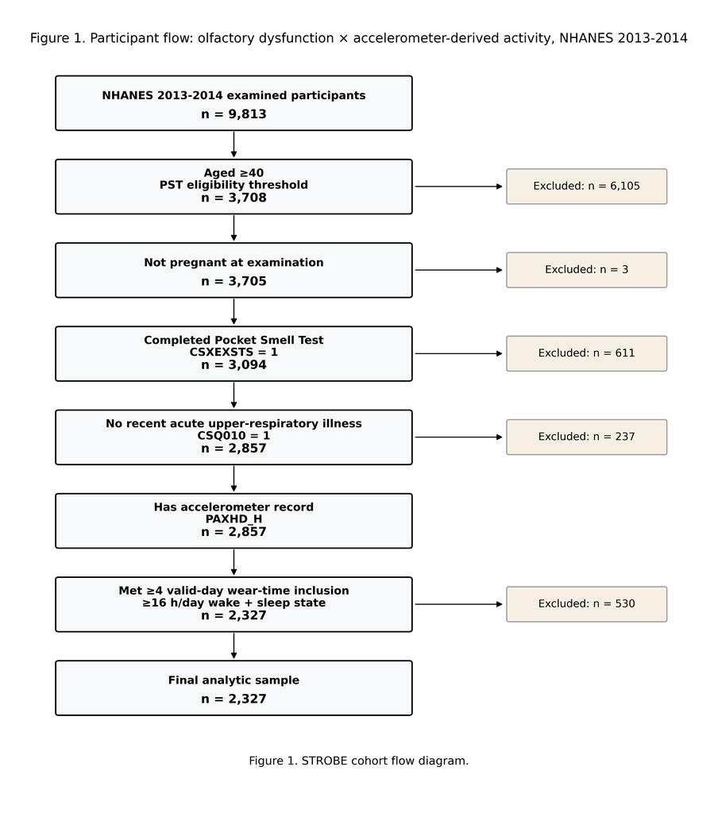

**Figure 1.** STROBE cohort flow diagram.

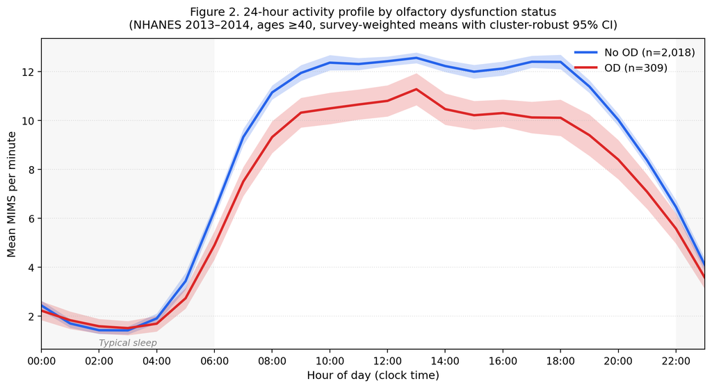

Figure 2. Twenty-four-hour activity profile by olfactory dysfunction status.

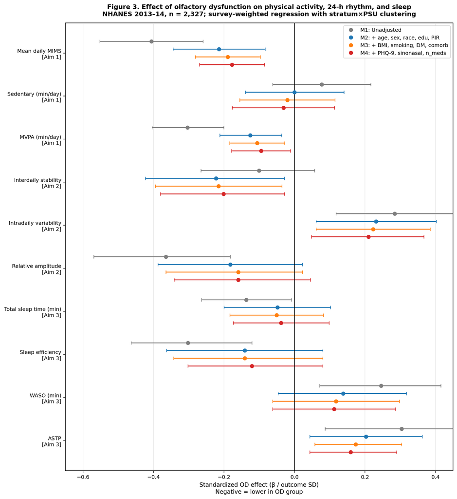

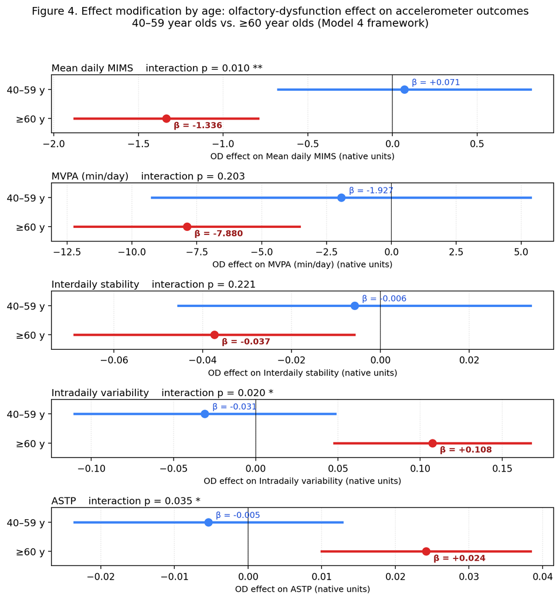

Figure 4. Age-stratified effect modification for OD-associated activity differences.

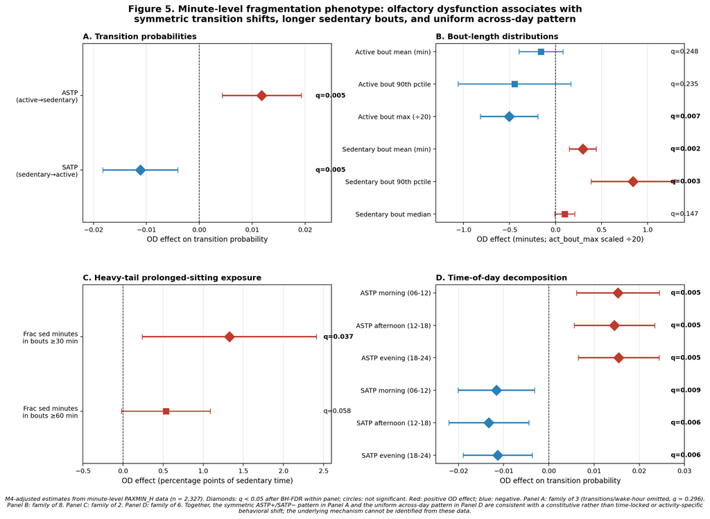

Figure 5. Minute-level fragmentation phenotype: ASTP/SATP symmetry, bout structure, prolonged sitting, and time-of-day decomposition.